# Workflow part II: ASV Inference and Taxon Assignment

## Goals

Process metabarcoding reads, post-adapter removal, including:

- Evaluation of read quality
- Quality trimming and filtering
- Error correction, denoising
- ASV inference
- Read merging
- Taxonomy assignment

## Before We Get Started

### Notes

- This documented was adapted from [Callahan et al. 2006](https://f1000research.com/articles/5-1492/v2) by Matthew Willman, with further edits by Soledad Benitez Ponce and Jelmer Poelstra.
- To convert an `Rmd` (R Markdown) file to an R script, type the following in an R console: `knitr::purl(input='<filename>.Rmd')`. (You can download this `Rmd` file by clicking the `Code` button in the top-right of this page – but we will open it at OSC.)

### Start an RStudio Server job at OSC

For more detailed instructions of the first steps, see this section from our intro to R session.

## Step 1: Getting Started

Print some information to screen for when running this script as a job:

```r
print('Starting ASV inference script...')
```

```
## [1] "Starting ASV inference script..."
```

```r
Sys.time()
```

```
## [1] "2020-12-15 17:36:50 EST"
```

```r
cat('Working directory:', getwd(), '\n')
```

```
## Working directory: /home/jelmer/Dropbox/mcic/teach/wsh/2020-12_microbiom/OSC/master
```

### Set the number of cores

Most dada2 functions can use multiple cores. Because we are on a cluster and we have reserved only part of a node, auto-detection of the number of cores will not be appropriate (the program will detect more cores than we have available). Therefore, we should specify the appropriate number of cores in our function call below.

We will set the number of cores here, assumes you requested 4 cores in your job submission (change if needed):

```r
n_cores <- 4
```

### Install and load packages

To save time, we have already installed all the necessary R packages at OSC into a custom library. To add this library for the current R session:

```r
#.libPaths(new = '/fs/project/PAS0471/.R/4.0/')
```

Then, load the packages:

```r
print('Loading packages...')
```

```
## [1] "Loading packages..."
```

```r
packages <- c('tidyverse', 'gridExtra', 'dada2',
              'phyloseq', 'DECIPHER', 'phangorn')
pacman::p_load(char = packages)

# If you wanted to install and load these packages yourself,
# just make sure you have the pacman package installed:
## install.packages('pacman')
# Then, the code above would work, as it will install pacakes as needed.
```

### Set the file paths

We’ll set most of the file paths upfront, which will make it easier to change things or troubleshoot.

```r
# Dir with input fastq files:
indir <- 'data/processed/fastq_trimmed'

# Dirs for output:
filter_dir <- 'data/processed/fastq_filtered'
outdir <- 'analysis/ASV_inference'

dir.create(filter_dir, showWarnings = FALSE, recursive = TRUE)
dir.create(outdir, showWarnings = FALSE, recursive = TRUE)

# Fasta file with training data:
# (Check for an up-to-date version at <https://benjjneb.github.io/dada2/training.html>)
tax_key <- 'data/ref/silva_nr99_v138_train_set.fa'

# File with sample metadata:
metadata_file <- 'metadata/sample_meta.txt'
```

### Assign fastq files to forward and reverse reads

We will assign the fastq files that we processed with `cutadapt` to two vectors: one with files with forward reads, and one with files with reverse reads. These files can be distinguished by having “R1” (forward) and “R2” (reverse) in their names.

```r
fastqs_raw_F <- sort(list.files(indir, pattern = '_R1_001.fastq.gz', full.names = TRUE))
fastqs_raw_R <- sort(list.files(indir, pattern = '_R2_001.fastq.gz', full.names = TRUE))

print('First fastq files:')
```

```
## [1] "First fastq files:"
```

```r
head(fastqs_raw_F)
```

```
## [1] "data/processed/fastq_trimmed/101-S1-V4-V5_S1_L001_R1_001.fastq.gz"
## [2] "data/processed/fastq_trimmed/101-S4-V4-V5_S49_L001_R1_001.fastq.gz"
## [3] "data/processed/fastq_trimmed/102-S4-V4-V5_S50_L001_R1_001.fastq.gz"
## [4] "data/processed/fastq_trimmed/103-S4-V4-V5_S51_L001_R1_001.fastq.gz"
## [5] "data/processed/fastq_trimmed/104-S4-V4-V5_S52_L001_R1_001.fastq.gz"
## [6] "data/processed/fastq_trimmed/201-S4-V4-V5_S53_L001_R1_001.fastq.gz"
```

### Check sample IDs

We’ll get the sample IDs from the fastq file names and from a file with metadata, and will check if they are the same. First we’ll prepare the metadata:

```r
print('Load and prepare sample metadata...')
```

```
## [1] "Load and prepare sample metadata..."
```

```r
metadata_df <- read.table(file = metadata_file, sep = "\t", header = TRUE)

colnames(metadata_df)[1] <- 'SampleID'
rownames(metadata_df) <- metadata_df$SampleID

print('First fastq files:')
```

```
## [1] "First fastq files:"
```

```r
head(metadata_df)
```

```
##        SampleID Experiment  Treatment Timepoint Block Plot
## blankM   blankM    control soil_blank      <NA>  <NA> <NA>
## H20         H20    control      water      <NA>  <NA> <NA>
## Zymo       Zymo    control   Zymo_mix      <NA>  <NA> <NA>
## 101-S1   101-S1        HCC         T1        S1    R1 P101
## 101-S4   101-S4        HCC         T1        S4    R1 P101
## 102-S4   102-S4        HCC         T4        S4    R1 P102
##        read_ct_ITS7ngs.ITS4ngsuni read_ct_V4.V5 PCR_prod_ITS7ngs.ITS4ngsuni
## blankM                       1721         29042                    0.038999
## H20                         29601          1463                    0.036260
## Zymo                       103820         93064                    1.272282
## 101-S1                     127441        140005                    0.394874
## 101-S4                     133809        180836                    0.541573
## 102-S4                     102013        126495                    0.649498
##        PCR_prod_V4.V5
## blankM       0.160996
## H20          0.010000
## Zymo         1.083145
## 101-S1       0.464003
## 101-S4       0.629419
## 102-S4       0.746320
```

Let’s compare the sample IDs from the metadata with the *fastq* filenames:

```r
print('IDs from metadata:')
```

```
## [1] "IDs from metadata:"
```

```r
metadata_df$SampleID
```

```
##  [1] "blankM" "H20"    "Zymo"   "101-S1" "101-S4" "102-S4" "103-S1" "103-S4"
##  [9] "104-S1" "104-S4" "201-S4" "202-S1" "202-S4" "203-S1" "203-S4" "204-S1"
## [17] "204-S4" "301-S1" "301-S4" "302-S4" "303-S1" "303-S4" "304-S1" "304-S4"
## [25] "401-S1" "401-S4" "402-S1" "402-S4" "403-S1" "403-S4" "404-S4" "501-S4"
## [33] "501S4"  "502-S1" "502-S4" "503-S1" "503-S4" "504-S1" "504-S4" "601-S1"
## [41] "601-S4" "602-S4" "603-S1" "603-S4" "604-S1" "604-S4"
```

```r
print('Fastq file names:')
```

```
## [1] "Fastq file names:"
```

```r
head(basename(fastqs_raw_F))    # basename() strips the dir name from the filename
```

```
## [1] "101-S1-V4-V5_S1_L001_R1_001.fastq.gz"
## [2] "101-S4-V4-V5_S49_L001_R1_001.fastq.gz"
## [3] "102-S4-V4-V5_S50_L001_R1_001.fastq.gz"
## [4] "103-S4-V4-V5_S51_L001_R1_001.fastq.gz"
## [5] "104-S4-V4-V5_S52_L001_R1_001.fastq.gz"
## [6] "201-S4-V4-V5_S53_L001_R1_001.fastq.gz"
```

To extract the sample IDs from the *fastq* file names, we remove everything after “-V4-V5” from the file names using the `sub()` function:

```r
# sub() arguments: sub(pattern, replacement, vector)
sampleIDs <- sub("-V4-V5_.*", "", basename(fastqs_raw_F))
```

We can check whether the IDs from the *fastq* files and the metadata dataframe are the same:

```r
print('Are the sample IDs from the metadata and the fastq files the same?')
```

```
## [1] "Are the sample IDs from the metadata and the fastq files the same?"
```

```r
identical(sort(metadata_df$SampleID), sampleIDs)
```

```
## [1] FALSE
```

```r
print('Are any samples missing from the fastq files?')
```

```
## [1] "Are any samples missing from the fastq files?"
```

```r
setdiff(sort(metadata_df$SampleID), sampleIDs)
```

```
## [1] "103-S1" "104-S1" "501S4"
```

```r
print('Are any samples missing from the metadata?')
```

```
## [1] "Are any samples missing from the metadata?"
```

```r
setdiff(sampleIDs, sort(metadata_df$SampleID))
```

```
## character(0)
```

As it turns out, we don’t have sequences for three samples in the metadata.

## Step 2: QC

### Plot sequence quality data

*DADA2* provide a function to plot the average base quality across sequence reads, `plotQualityProfile()`. You can generate and evaluate plots for each sample, e.g. the forward reads and reverse reads side-by-side like so:

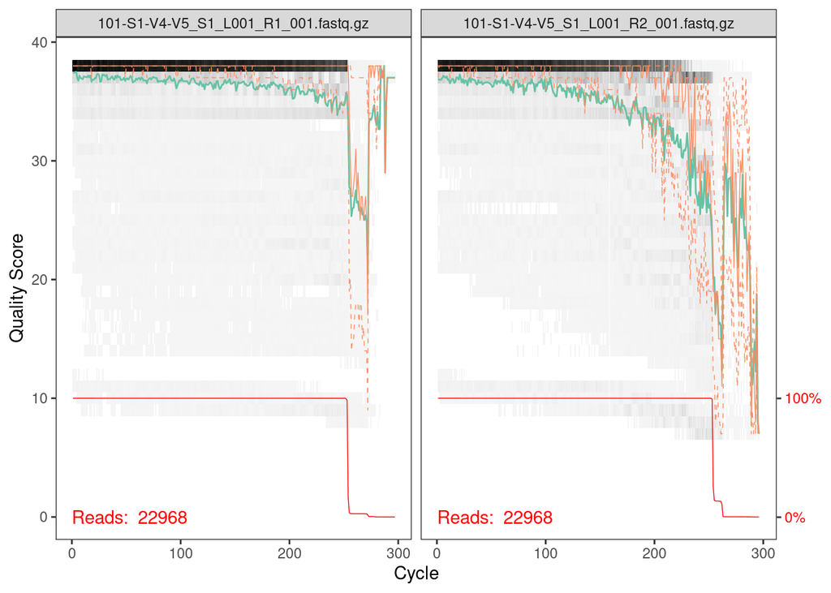

```r
plotQualityProfile(c(fastqs_raw_F[1], fastqs_raw_R[1]))
```

This code will generate a pdf file with plots for each sample:

```r
pdf(file.path(outdir, 'error_profiles.pdf'))               # Open a pdf file
for (sample_idx in 1:length(fastqs_raw_F)) {               # Loop through samples
  print(plotQualityProfile(                                # Print plots into pdf
    c(fastqs_raw_F[sample_idx], fastqs_raw_R[sample_idx])) # F and R together
    )
}
dev.off()                                                  # Close the pdf file
```

It is a good idea to run the [`fastqc`](https://www.bioinformatics.babraham.ac.uk/projects/fastqc/) program on your *fastq* files for more extensive QC. This is a stand-alone program that is easy to run from the command-line. When you have many samples, as is often the case, `fastqc`’s results can moreover be nicely summarized using [`multiqc`](https://multiqc.info/. In the interest of time, we skipped these steps during this workshop.

## Step 3: Filtering and Quality Trimming

We will now perform quality filtering (removing poor-quality reads) and trimming (removing poor-quality bases) on the *fastq* files using *DADA2*’s `filterAndTrim()` function.

The `filterAndTrim()` function will write the filtered and trimmed reads to new *fastq* files. Therefore, we first define the file names for the new files:

```r
fastqs_filt_F <- file.path(filter_dir, paste0(sampleIDs, '_F_filt.fastq'))
fastqs_filt_R <- file.path(filter_dir, paste0(sampleIDs, '_R_filt.fastq'))
```

The `truncLen` argument of `filterAndTrim()` defines the read lengths (for forward and reverse reads, respectively) beyond which additional bases should be removed, and these values should be based on the sequence quality visualized above. The trimming length can thus be different for forward and reverse reads, which is good because reverse reads are often of worse quality.

It is also suggested to trim the first 10 nucleotides of each read (`trimLeft` argument), since these positions are likely to contain errors.

`maxEE` is an important argument that will let DADA2 trim reads based on the maximum numbers of Expected Errors (EE) given the quality scores of the reads’ bases.

```r
print('Filtering and Trimming...')
```

```
## [1] "Filtering and Trimming..."
```

```r
Sys.time()  # Print the time to keep track of running time for individual steps
```

```
## [1] "2020-12-15 17:37:44 EST"
```

```r
filter_results <-
  filterAndTrim(fastqs_raw_F, fastqs_filt_F,
                fastqs_raw_R, fastqs_filt_R,
                truncLen = c(250,210),
                trimLeft = 10,
                maxN = 0,
                maxEE = c(2,2),
                truncQ = 2,
                rm.phix = FALSE,
                multithread = n_cores,
                compress = FALSE, verbose = TRUE)
print('...Done!')
```

```
## [1] "...Done!"
```

```r
Sys.time()
```

```
## [1] "2020-12-15 17:37:56 EST"
```

```r
head(filter_results)
```

```
##                                       reads.in reads.out
## 101-S1-V4-V5_S1_L001_R1_001.fastq.gz     22968     20587
## 101-S4-V4-V5_S49_L001_R1_001.fastq.gz    29552     26664
## 102-S4-V4-V5_S50_L001_R1_001.fastq.gz    20668     18832
## 103-S4-V4-V5_S51_L001_R1_001.fastq.gz    18894     17027
## 104-S4-V4-V5_S52_L001_R1_001.fastq.gz    20526     18400
## 201-S4-V4-V5_S53_L001_R1_001.fastq.gz    15411     13890
```

## Step 4: Dereplication & Error Training

Next, we want to “dereplicate” the filtered *fastq* files. During dereplication, we condense the data by collapsing together all reads that encode the same sequence, which significantly reduces later computation times.

```r
fastqs_derep_F <- derepFastq(fastqs_filt_F, verbose = FALSE)
fastqs_derep_R <- derepFastq(fastqs_filt_R, verbose = FALSE)

names(fastqs_derep_F) <- sampleIDs
names(fastqs_derep_R) <- sampleIDs
```

The *DADA2* algorithm makes use of a parametric error model (`err`) and every amplicon dataset has a different set of error rates. The `learnErrors` method learns this error model from the data, by alternating estimation of the error rates and inference of sample composition until they converge on a jointly consistent solution.

```r
print('Learning errors...')
```

```
## [1] "Learning errors..."
```

```r
Sys.time()
```

```
## [1] "2020-12-15 17:39:43 EST"
```

```r
err_F <- learnErrors(fastqs_derep_F, multithread = n_cores, verbose = TRUE)
```

```
## 101772240 total bases in 424051 reads from 30 samples will be used for learning the error rates.
## Initializing error rates to maximum possible estimate.
## selfConsist step 1 ..............................
##    selfConsist step 2
##    selfConsist step 3
##    selfConsist step 4
##    selfConsist step 5
##    selfConsist step 6
## Convergence after  6  rounds.
```

```r
err_R <- learnErrors(fastqs_derep_R, multithread = n_cores, verbose = TRUE)
```

```
## 101413800 total bases in 507069 reads from 37 samples will be used for learning the error rates.
## Initializing error rates to maximum possible estimate.
## selfConsist step 1 .....................................
##    selfConsist step 2
##    selfConsist step 3
##    selfConsist step 4
##    selfConsist step 5
##    selfConsist step 6
##    selfConsist step 7
## Convergence after  7  rounds.
```

```r
print('...Done!')
```

```
## [1] "...Done!"
```

```r
Sys.time()
```

```
## [1] "2020-12-15 17:58:15 EST"
```

We’ll plot errors to verify that error rates have been reasonable well-estimated. Pay attention to the fit between observed error rates (points) and fitted error rates (lines):

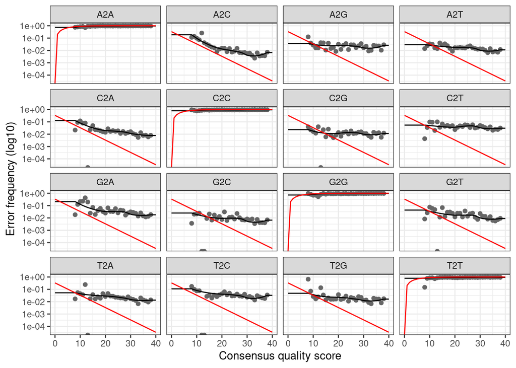

```r
plotErrors(err_F, nominalQ = TRUE)
```

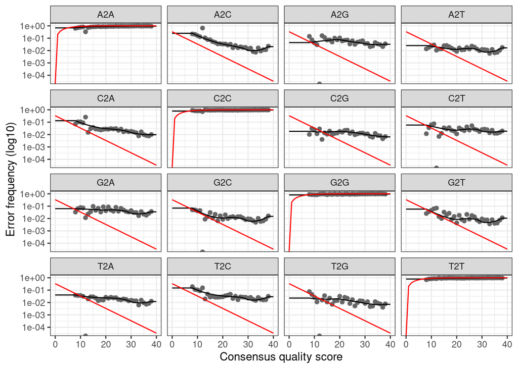

```r
plotErrors(err_R, nominalQ = TRUE)
```

## Step 5: Infer ASVs

We will now run the core *dada* algorithm, which infers Amplicon Sequence Variants (ASVs) from the sequences.

This step is quite computationally intensive, and for this tutorial, we will therefore perform independent inference for each sample (`pool = FALSE`), which will keep the computation time down.

Pooling will increase computation time, especially if you have many samples, but will improve detection of rare variants seen once or twice in an individual sample, but many times across all samples. Therefore, for your own analysis, you will likely want to use pooling, though [“pseudo-pooling” is also an option](https://benjjneb.github.io/dada2/pseudo.html).

```r
print('Inferring ASVs (running the dada algorithm)...')
```

```
## [1] "Inferring ASVs (running the dada algorithm)..."
```

```r
Sys.time()
```

```
## [1] "2020-12-15 17:58:17 EST"
```

```r
dada_Fs <- dada(fastqs_derep_F, err = err_F, pool = FALSE, multithread = n_cores)
```

```
## Sample 1 - 20587 reads in 11912 unique sequences.
## Sample 2 - 26664 reads in 18924 unique sequences.
## Sample 3 - 18832 reads in 14124 unique sequences.
## Sample 4 - 17027 reads in 12938 unique sequences.
## Sample 5 - 18400 reads in 13709 unique sequences.
## Sample 6 - 13890 reads in 10701 unique sequences.
## Sample 7 - 10653 reads in 7754 unique sequences.
## Sample 8 - 15501 reads in 12495 unique sequences.
## Sample 9 - 11463 reads in 7914 unique sequences.
## Sample 10 - 16660 reads in 12549 unique sequences.
## Sample 11 - 6452 reads in 5207 unique sequences.
## Sample 12 - 13391 reads in 9915 unique sequences.
## Sample 13 - 9108 reads in 4464 unique sequences.
## Sample 14 - 14732 reads in 11046 unique sequences.
## Sample 15 - 17704 reads in 13544 unique sequences.
## Sample 16 - 10184 reads in 7074 unique sequences.
## Sample 17 - 16977 reads in 12989 unique sequences.
## Sample 18 - 17038 reads in 11455 unique sequences.
## Sample 19 - 15461 reads in 12148 unique sequences.
## Sample 20 - 13600 reads in 9418 unique sequences.
## Sample 21 - 13785 reads in 10744 unique sequences.
## Sample 22 - 10007 reads in 7397 unique sequences.
## Sample 23 - 13170 reads in 10212 unique sequences.
## Sample 24 - 9354 reads in 7054 unique sequences.
## Sample 25 - 13632 reads in 11245 unique sequences.
## Sample 26 - 11997 reads in 9402 unique sequences.
## Sample 27 - 12762 reads in 7088 unique sequences.
## Sample 28 - 9438 reads in 6332 unique sequences.
## Sample 29 - 13708 reads in 9840 unique sequences.
## Sample 30 - 11874 reads in 7934 unique sequences.
## Sample 31 - 7404 reads in 6148 unique sequences.
## Sample 32 - 11950 reads in 7843 unique sequences.
## Sample 33 - 12215 reads in 9898 unique sequences.
## Sample 34 - 11357 reads in 7668 unique sequences.
## Sample 35 - 12819 reads in 10280 unique sequences.
## Sample 36 - 17115 reads in 13034 unique sequences.
## Sample 37 - 10158 reads in 6924 unique sequences.
## Sample 38 - 15814 reads in 12189 unique sequences.
## Sample 39 - 13279 reads in 8208 unique sequences.
## Sample 40 - 11744 reads in 9143 unique sequences.
## Sample 41 - 4368 reads in 545 unique sequences.
## Sample 42 - 150 reads in 54 unique sequences.
## Sample 43 - 13995 reads in 6218 unique sequences.
```

```r
dada_Rs <- dada(fastqs_derep_R, err = err_R, pool = FALSE, multithread = n_cores)
```

```
## Sample 1 - 20587 reads in 11751 unique sequences.
## Sample 2 - 26664 reads in 17610 unique sequences.
## Sample 3 - 18832 reads in 12994 unique sequences.
## Sample 4 - 17027 reads in 12182 unique sequences.
## Sample 5 - 18400 reads in 12910 unique sequences.
## Sample 6 - 13890 reads in 10029 unique sequences.
## Sample 7 - 10653 reads in 7480 unique sequences.
## Sample 8 - 15501 reads in 11594 unique sequences.
## Sample 9 - 11463 reads in 7622 unique sequences.
## Sample 10 - 16660 reads in 11811 unique sequences.
## Sample 11 - 6452 reads in 4882 unique sequences.
## Sample 12 - 13391 reads in 9454 unique sequences.
## Sample 13 - 9108 reads in 4426 unique sequences.
## Sample 14 - 14732 reads in 10156 unique sequences.
## Sample 15 - 17704 reads in 12526 unique sequences.
## Sample 16 - 10184 reads in 6987 unique sequences.
## Sample 17 - 16977 reads in 12281 unique sequences.
## Sample 18 - 17038 reads in 11144 unique sequences.
## Sample 19 - 15461 reads in 11403 unique sequences.
## Sample 20 - 13600 reads in 9092 unique sequences.
## Sample 21 - 13785 reads in 10225 unique sequences.
## Sample 22 - 10007 reads in 7311 unique sequences.
## Sample 23 - 13170 reads in 9521 unique sequences.
## Sample 24 - 9354 reads in 6909 unique sequences.
## Sample 25 - 13632 reads in 10603 unique sequences.
## Sample 26 - 11997 reads in 8846 unique sequences.
## Sample 27 - 12762 reads in 6770 unique sequences.
## Sample 28 - 9438 reads in 6366 unique sequences.
## Sample 29 - 13708 reads in 9332 unique sequences.
## Sample 30 - 11874 reads in 7681 unique sequences.
## Sample 31 - 7404 reads in 5879 unique sequences.
## Sample 32 - 11950 reads in 7686 unique sequences.
## Sample 33 - 12215 reads in 9301 unique sequences.
## Sample 34 - 11357 reads in 7563 unique sequences.
## Sample 35 - 12819 reads in 9578 unique sequences.
## Sample 36 - 17115 reads in 12018 unique sequences.
## Sample 37 - 10158 reads in 6869 unique sequences.
## Sample 38 - 15814 reads in 11416 unique sequences.
## Sample 39 - 13279 reads in 8221 unique sequences.
## Sample 40 - 11744 reads in 8657 unique sequences.
## Sample 41 - 4368 reads in 514 unique sequences.
## Sample 42 - 150 reads in 49 unique sequences.
## Sample 43 - 13995 reads in 5068 unique sequences.
```

```r
print('...Done.')
```

```
## [1] "...Done."
```

```r
Sys.time()
```

```
## [1] "2020-12-15 18:02:00 EST"
```

Let’s inspect one of the resulting objects:

```r
dada_Fs[[1]]
```

```
## dada-class: object describing DADA2 denoising results
## 804 sequence variants were inferred from 11912 input unique sequences.
## Key parameters: OMEGA_A = 1e-40, OMEGA_C = 1e-40, BAND_SIZE = 16
```

## Step 6: Merge Read Pairs

In this step, we will first merge the forward and reverse read pairs: the fragment that we amplified with our primers was short enough to generate lots of overlap among the sequences from the two directions.

```r
mergers <- mergePairs(dada_Fs, fastqs_derep_F,
                      dada_Rs, fastqs_derep_R,
                      verbose = TRUE)
```

```
## 15174 paired-reads (in 657 unique pairings) successfully merged out of 17170 (in 1182 pairings) input.
```

```
## 18822 paired-reads (in 617 unique pairings) successfully merged out of 21702 (in 1334 pairings) input.
```

```
## 12203 paired-reads (in 438 unique pairings) successfully merged out of 14599 (in 990 pairings) input.
```

```
## 11228 paired-reads (in 349 unique pairings) successfully merged out of 13089 (in 804 pairings) input.
```

```
## 11977 paired-reads (in 415 unique pairings) successfully merged out of 14228 (in 939 pairings) input.
```

```
## 8733 paired-reads (in 302 unique pairings) successfully merged out of 10403 (in 652 pairings) input.
```

```
## 6067 paired-reads (in 292 unique pairings) successfully merged out of 7911 (in 594 pairings) input.
```

```
## 9224 paired-reads (in 314 unique pairings) successfully merged out of 11520 (in 731 pairings) input.
```

```
## 7866 paired-reads (in 371 unique pairings) successfully merged out of 9112 (in 660 pairings) input.
```

```
## 10839 paired-reads (in 422 unique pairings) successfully merged out of 12749 (in 869 pairings) input.
```

```
## 3045 paired-reads (in 155 unique pairings) successfully merged out of 4265 (in 306 pairings) input.
```

```
## 8843 paired-reads (in 347 unique pairings) successfully merged out of 10120 (in 695 pairings) input.
```

```
## 6519 paired-reads (in 181 unique pairings) successfully merged out of 7587 (in 347 pairings) input.
```

```
## 9875 paired-reads (in 322 unique pairings) successfully merged out of 11766 (in 717 pairings) input.
```

```
## 11080 paired-reads (in 418 unique pairings) successfully merged out of 13585 (in 960 pairings) input.
```

```
## 6362 paired-reads (in 364 unique pairings) successfully merged out of 7619 (in 637 pairings) input.
```

```
## 10856 paired-reads (in 381 unique pairings) successfully merged out of 13017 (in 906 pairings) input.
```

```
## 11444 paired-reads (in 494 unique pairings) successfully merged out of 13383 (in 987 pairings) input.
```

```
## 9218 paired-reads (in 317 unique pairings) successfully merged out of 11473 (in 764 pairings) input.
```

```
## 9098 paired-reads (in 383 unique pairings) successfully merged out of 10735 (in 722 pairings) input.
```

```
## 8734 paired-reads (in 329 unique pairings) successfully merged out of 10264 (in 685 pairings) input.
```

```
## 6138 paired-reads (in 287 unique pairings) successfully merged out of 7375 (in 541 pairings) input.
```

```
## 7976 paired-reads (in 320 unique pairings) successfully merged out of 9760 (in 707 pairings) input.
```

```
## 5425 paired-reads (in 259 unique pairings) successfully merged out of 6807 (in 502 pairings) input.
```

```
## 7460 paired-reads (in 268 unique pairings) successfully merged out of 9643 (in 635 pairings) input.
```

```
## 7248 paired-reads (in 269 unique pairings) successfully merged out of 8848 (in 617 pairings) input.
```

```
## 9421 paired-reads (in 472 unique pairings) successfully merged out of 10506 (in 775 pairings) input.
```

```
## 6196 paired-reads (in 313 unique pairings) successfully merged out of 7375 (in 574 pairings) input.
```

```
## 8947 paired-reads (in 327 unique pairings) successfully merged out of 10610 (in 729 pairings) input.
```

```
## 7764 paired-reads (in 394 unique pairings) successfully merged out of 9293 (in 693 pairings) input.
```

```
## 3899 paired-reads (in 162 unique pairings) successfully merged out of 4966 (in 354 pairings) input.
```

```
## 8331 paired-reads (in 403 unique pairings) successfully merged out of 9554 (in 689 pairings) input.
```

```
## 6657 paired-reads (in 264 unique pairings) successfully merged out of 8738 (in 645 pairings) input.
```

```
## 7524 paired-reads (in 404 unique pairings) successfully merged out of 8689 (in 688 pairings) input.
```

```
## 7419 paired-reads (in 276 unique pairings) successfully merged out of 9371 (in 649 pairings) input.
```

```
## 10806 paired-reads (in 372 unique pairings) successfully merged out of 13282 (in 895 pairings) input.
```

```
## 6429 paired-reads (in 334 unique pairings) successfully merged out of 7670 (in 600 pairings) input.
```

```
## 9668 paired-reads (in 343 unique pairings) successfully merged out of 12138 (in 826 pairings) input.
```

```
## 9358 paired-reads (in 450 unique pairings) successfully merged out of 10747 (in 782 pairings) input.
```

```
## 6864 paired-reads (in 271 unique pairings) successfully merged out of 8791 (in 651 pairings) input.
```

```
## 4257 paired-reads (in 29 unique pairings) successfully merged out of 4342 (in 34 pairings) input.
```

```
## 142 paired-reads (in 23 unique pairings) successfully merged out of 142 (in 23 pairings) input.
```

```
## 11423 paired-reads (in 187 unique pairings) successfully merged out of 13340 (in 890 pairings) input.
```

Just like tables can be saved in R using `write.table` or `write.csv`, R *objects* can be saved using `saveRDS`. The resulting *rds* file can then be loaded into an R environment using `readRDS`. This is a convenient way to save R objects that require a lot of computation time.

We should not be needing the very large dereplicated sequence objects anymore, but to be able to quickly restart our analysis from a new R session if necessary, we now save these objects to *rds* files. And after that, we can safely remove these objects from our environment.

```r
saveRDS(fastqs_derep_F, file = file.path(outdir, 'fastqs_derep_F.rds'))
saveRDS(fastqs_derep_R, file = file.path(outdir, 'fastqs_derep_R.rds'))

rm(fastqs_derep_F, fastqs_derep_R) # Remove objects from environment
```

## Step 7: Construct a Sequence Table

Next, we construct an amplicon sequence variant table (ASV) table:

```r
seqtab_all <- makeSequenceTable(mergers)

# The dimensions of the object are the nr of samples (rows) and the nr of ASVs (columns):
dim(seqtab_all)
```

```
## [1]   43 4076
```

Let’s inspect the distribution of sequence lengths:

```r
table(nchar(getSequences(seqtab_all)))
```

```
##
##  240  241  251  252  253  254  259  262  264  268  283
## 4048    1    7    2   10    1    1    1    1    3    1
```

```r
# If you need to remove sequences of a particular length (e.g. too long):
# seqtab2 <- seqtab[, nchar(colnames(seqtab_all)) %in% seq(250,256)]
```

## Step 8: Remove Chimeras

Now, we will remove chimeras. The *dada* algorithm models and removes substitution errors, but chimeras are another importance source of spurious sequences in amplicon sequencing. Chimeras are [formed during PCR amplification](https://www.ncbi.nlm.nih.gov/pmc/articles/PMC3044863/). When one sequence is incompletely amplified, the incomplete amplicon primes the next amplification step, yielding a spurious amplicon. The result is a sequence read which is half of one sample sequence and half another.

Fortunately, the accuracy of the sequence variants after denoising makes identifying chimeras simpler than it is when dealing with fuzzy OTUs. Chimeric sequences are identified if they can be exactly reconstructed by combining a left-segment and a right-segment from two more abundant “parent” sequences.

```r
seqtab <- removeBimeraDenovo(seqtab_all,
                             method = 'consensus',
                             multithread = n_cores,
                             verbose = TRUE)
```

```
## Identified 199 bimeras out of 4076 input sequences.
```

```r
ncol(seqtab)
```

```
## [1] 3877
```

```r
# Proportion of retained sequences:
sum(seqtab) / sum(seqtab_all)
```

```
## [1] 0.9767404
```

We will save the `seqtab` object as an *rds* file:

```r
saveRDS(seqtab, file = file.path(outdir, 'seqtab_V4.rds'))
```

## Step 9: Generate a Summary Table

In this step, we will generate a summary table of the number of sequences processed and outputs of different steps of the pipeline.

This information is generally used to further evaluate characteristics and quality of the run, sample-to-sample variation, and resulting sequencing depth for each sample.

To get started, we will define a function `getN()` that will get the number of unique reads for a sample. Then, we apply `getN()` to each element of the `dada_Fs`, `dada_Rs`, and `mergers` objects, which gives us vectors with the number of unique reads for each samples, during each of these steps:

```r
getN <- function(x) {
  sum(getUniques(x))
}

denoised_F <- sapply(dada_Fs, getN)
denoised_R <- sapply(dada_Rs, getN)
merged <- sapply(mergers, getN)
```

We’ll join these vectors together with the “filter_results” dataframe, and the number of nonchimeric reads:

```r
nreads_summary <- data.frame(filter_results,
                             denoised_F,
                             denoised_R,
                             nonchim = rowSums(seqtab),
                             row.names = sampleIDs)
colnames(nreads_summary)[1:2] <- c('input', 'filtered')

# Have a look at the first few rows:
head(nreads_summary)
```

```
##        input filtered denoised_F denoised_R nonchim
## 101-S1 22968    20587      17960      18234   15120
## 101-S4 29552    26664      22429      23511   18796
## 102-S4 20668    18832      15243      16034   12194
## 103-S4 18894    17027      13660      14402   11184
## 104-S4 20526    18400      14780      15689   11958
## 201-S4 15411    13890      10862      11564    8717
```

Finally, we’ll write this table to file:

```r
write.table(nreads_summary, file = file.path(outdir, 'nreads_summary.txt'),
            sep = "\t", quote = FALSE, row.names = TRUE)
```

## Step 10: Assign Taxonomy to ASVs

Now, we will assign taxonomy to our ASVs.

Depending on the marker gene and the data, you will have to choose the appropriate reference file for this step. Several files have been formatted for taxonomy assignments in *DADA2* pipeline and are available at the [DADA2 website](https://benjjneb.github.io/dada2/index.html).

```r
print('Assigning taxa to ASVs...')
```

```
## [1] "Assigning taxa to ASVs..."
```

```r
Sys.time()
```

```
## [1] "2020-12-15 18:03:31 EST"
```

```r
taxa <- assignTaxonomy(seqtab, tax_key, multithread = n_cores)
colnames(taxa) <- c('Kingdom', 'Phylum', 'Class', 'Order', 'Family', 'Genus')

print('...Done.')
```

```
## [1] "...Done."
```

```r
Sys.time()
```

```
## [1] "2020-12-15 18:09:54 EST"
```

## Step 11: Generate Output Files

In this last step, we will generate output files from the *DADA2* outputs that are formatted for downstream analysis in *phyloseq*. First, we will write a *fasta* file with the final ASV sequences. (This *fasta* file can also be used for phylogenetic tree inference with different R packages.)

```r
# Prepare sequences and headers:
asv_seqs <- colnames(seqtab)
asv_headers <- paste('>ASV', 1:ncol(seqtab), sep = '_')

# Interleave headers and sequences:
asv_fasta <- c(rbind(asv_headers, asv_seqs))

# Write fasta file:
write(asv_fasta, file = file.path(outdir, 'ASVs.fa'))
```

Now, we build the final *phyloseq* object. Notes:

- While we will not add a phylogenetic tree now, this can also be added to a *phyloseq* object.
- Our metadata dataframe contains three samples that we don’t have sequences for. However, this is not a problem: *phyloseq* will match the sample IDs in the metadata with those in the OTU table, and disregard IDs not present in the OTU table.

```r
ps <- phyloseq(otu_table(seqtab, taxa_are_rows = FALSE),
               sample_data(metadata_df),
               tax_table(taxa))

# Saves the phyloseq object as an .rds file (which can be imported directly by phyloseq):
saveRDS(ps, file = file.path(outdir, 'ps_V4.rds'))
```

Report that we are done!

```r
print('Done with ASV inference.')
```

```
## [1] "Done with ASV inference."
```

## Resources

- [Callahan et al. 2006: “Bioconductor Workflow for Microbiome Data Analysis: from raw reads to community analyses”](https://f1000research.com/articles/5-1492/v2)
- [`dada2` documentation and tutorials](https://benjjneb.github.io/dada2/index.html)
- [Taxonomic references for `dada2`](https://benjjneb.github.io/dada2/training.html)
- [`cutadapt` documentation and tutorials](https://cutadapt.readthedocs.io/en/stable/index.html)

## Bonus: Phylogenetic Tree Estimation

A phylogenetic tree can be estimated for the sequence data you generated. Depending on the number of ASVs recovered and the phylogenetic tree algorithm of choice, this step could take several days. Simpler trees will be less computationally intensive. Depending on the marker gene you are working on, you may or may not choose to perform this step.

This step can be conducted after Step 10, and then the phylogeny can be included in the *phyloseq* object in Step 11.

```r
#seqtab<- readRDS('seqtab_V4.rds')

seqs <- getSequences(seqtab)

# This propagates to the tip labels of the tree.
# At this stage ASV labels are full ASV sequence
names(seqs) <- seqs
alignment <- AlignSeqs(DNAStringSet(seqs),
                       anchor = NA,
                       iterations = 5,
                       refinements = 5)

print('Computing pairwise distances from ASVs...')
Sys.time()
phang.align <- phyDat(as(alignment, 'matrix'), type = 'DNA')
dm <- dist.ml(phang.align)
treeNJ <- NJ(dm) # Note, tip order is not sequence order
fit = pml(treeNJ, data = phang.align)
print('...Done.')
Sys.time()

print('Fit GTR model...')
Sys.time()
fitGTR <- update(fit, k = 4, inv = 0.2)
print('...Done.')
Sys.time()

print('Computing likelihood of tree...')
Sys.time()
fitGTR <- optim.pml(fitGTR,
                    model = 'GTR',
                    optInv = TRUE,
                    optGamma = TRUE,
                    rearrangement = 'stochastic',
                    control = pml.control(trace = 0))
print('...Done'.)
Sys.time()
```

## Bonus: Submit script as an OSC job

Extract R code from this document:

```r
knitr::purl(input = 'markdown/07-ASV-inference.Rmd',
            output = 'scripts/02-ASV-inference.R')
```

Our script `02-ASV-inference.sh` with *SLURM* directives that will submit the R script from the shell using `Rscript`:

```bash
#!/bin/bash
#SBATCH --nodes=1
#SBATCH --ntasks-per-node=4
#SBATCH --time=2:00:00
#SBATCH --account=PAS0471

module load gnu/9.1.0
module load mkl/2019.0.5
module load R/4.0.2

Rscript scripts/02-ASV-inference.R
```

Submit the script:

```bash
sbatch scripts/02-ASV-inference.sh
```